# Introdução

Análise de Dados Bancários: Comportamento Financeiro de Clientes  
Neste projeto, desenvolvi e analisei um banco de dados fictício contendo informações financeiras de 1000 clientes de uma instituição bancária.  
O objetivo é entender o perfil financeiro dos clientes através de variáveis como idade, gênero, estado civil, saldo bancário, salário mensal, limite de cartão de crédito, score de crédito, número de empréstimos, tipo de conta, entre outros.  
A partir desse banco de dados, realizamos análises exploratórias para identificar padrões, tendências e insights estratégicos, como:  
• A média de idade dos clientes;  
• A relação entre saldo bancário e idade;  
• O impacto do score de crédito na quantidade de empréstimos;  
• Comparações salariais entre investidores e não investidores;  
• Diferenças no limite de crédito conforme o tipo de conta;  
• Evolução do número de clientes ao longo dos anos;  
• Distribuição de gênero entre os tipos de conta;  
• Perfil dos clientes inadimplentes.  
Essas análises são essenciais para apoiar decisões bancárias mais assertivas, como concessão de crédito, criação de produtos financeiros e definição de estratégias de retenção e atração de clientes.

# Importando bibliotecas

```python
import pandas as pd
import matplotlib.pyplot as plt
plt.style.use('seaborn-v0_8')
```

# Importando banco de dados da planilha excel.

```python
df = pd.read_excel('Documents/dados_bancarios.xlsx')
df.head()
```

|  | ID_Cliente | Idade | Gênero | Estado Civil | Saldo_Conta | Salario_Mensal | Limite_Cartao | Score_Credito | Numero_Emprestimos | Investimentos | Tipo_Conta | Data_Abertura_Conta |
| --- | --- | --- | --- | --- | --- | --- | --- | --- | --- | --- | --- | --- |
| 0 | 1 | 49 | Female | Married | 60700.26 | 38599.24 | 8968.06 | 893 | 0 | No | Savings | 2002-01-10 |
| 1 | 2 | 25 | Female | Single | 30969.50 | 34900.19 | 2158.31 | 315 | 2 | No | Salary | 2000-07-31 |
| 2 | 3 | 50 | Female | Widowed | 81276.72 | 33266.03 | 22714.89 | 635 | 5 | No | Checking | 2002-06-15 |
| 3 | 4 | 68 | Female | Married | 78764.75 | 6924.22 | 21405.32 | 840 | 3 | Yes | Student | 2008-06-08 |
| 4 | 5 | 44 | Female | Widowed | 16975.70 | 7367.26 | 13672.17 | 899 | 4 | No | Student | 2003-11-21 |

# Analise realizadas

```python
# 1. Média de idade dos clientes

media_idade = df['Idade'].mean()
print(f'Média de idade dos clientes: {media_idade:.0f} anos')
```

```
Média de idade dos clientes: 46 anos
```

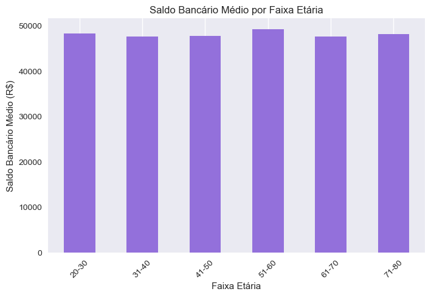

```python
# 2. Faixa de saldo bancário por idade

# Criar faixas etárias
bins = [20, 30, 40, 50, 60, 70, 80]
labels = ['20-30', '31-40', '41-50', '51-60', '61-70', '71-80']

df['Faixa_Idade'] = pd.cut(df['Idade'], bins=bins, labels=labels, right=True)

# Agrupar saldo médio por faixa etária
saldo_por_faixa = df.groupby('Faixa_Idade')['Saldo_Conta'].mean()

# Plotar o gráfico
plt.figure(figsize=(8,5))
saldo_por_faixa.plot(kind='bar', color='mediumpurple')
plt.title('Saldo Bancário Médio por Faixa Etária')
plt.xlabel('Faixa Etária')
plt.ylabel('Saldo Bancário Médio (R$)')
plt.grid(axis='y')
plt.xticks(rotation=45)
plt.show()
```

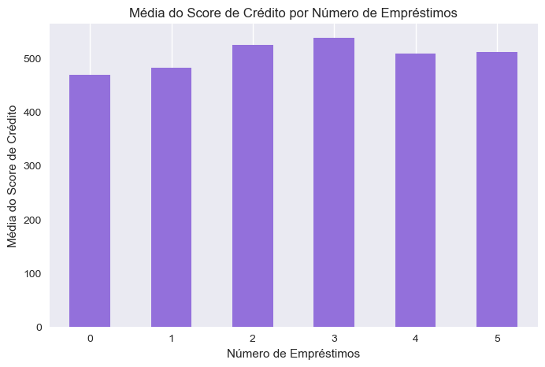

```python
# 3. Relação entre Score de Crédito e número de empréstimos


# Agrupar média do Score de Crédito para cada Número de Empréstimos
score_medio = df.groupby('Numero_Emprestimos')['Score_Credito'].mean()

# Plotar o gráfico
plt.figure(figsize=(8,5))
score_medio.plot(kind='bar', color='mediumpurple')
plt.title('Média do Score de Crédito por Número de Empréstimos')
plt.xlabel('Número de Empréstimos')
plt.ylabel('Média do Score de Crédito')
plt.grid(axis='y')
plt.xticks(rotation=0)
plt.show()
```

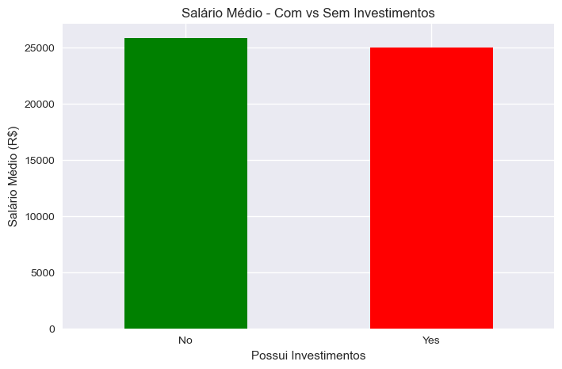

```python
# 4. Salário médio de quem possui investimentos vs quem não possui

salario_investimentos = df.groupby('Investimentos')['Salario_Mensal'].mean()

salario_investimentos.plot(kind='bar', figsize=(8,5), color=['green', 'red'])
plt.title('Salário Médio - Com vs Sem Investimentos')
plt.xlabel('Possui Investimentos')
plt.ylabel('Salário Médio (R$)')
plt.xticks(rotation=0)
plt.grid(True)
plt.show()
```

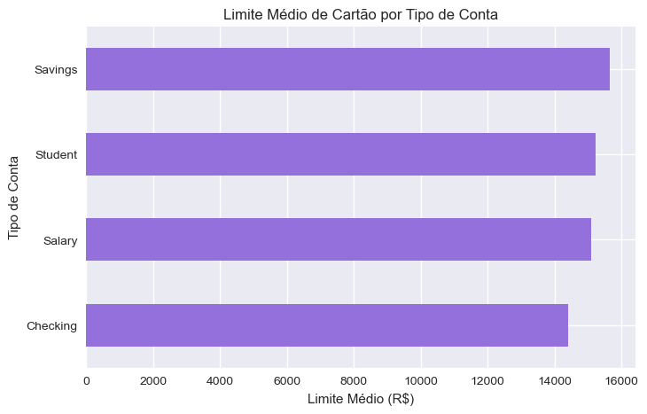

```python
# 5. Diferença de limite de cartão de crédito por tipo de conta

limite_tipo_conta = df.groupby('Tipo_Conta')['Limite_Cartao'].mean().sort_values()

limite_tipo_conta.plot(kind='barh', figsize=(8,5), color='mediumpurple')
plt.title('Limite Médio de Cartão por Tipo de Conta')
plt.xlabel('Limite Médio (R$)')
plt.ylabel('Tipo de Conta')
plt.grid(True)
plt.show()
```

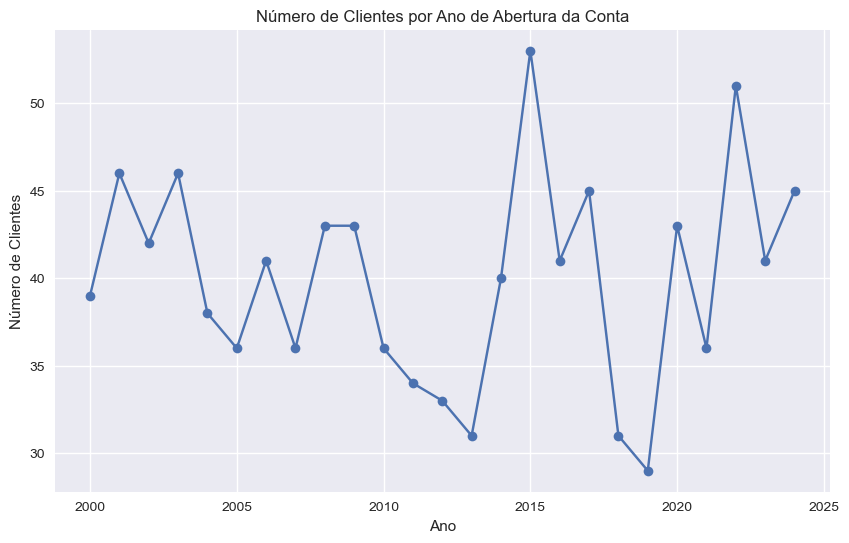

```python
# 6. Evolução dos clientes por ano de abertura da conta

df['Ano_Abertura'] = pd.to_datetime(df['Data_Abertura_Conta']).dt.year

clientes_por_ano = df['Ano_Abertura'].value_counts().sort_index()

clientes_por_ano.plot(kind='line', marker='o', figsize=(10,6))
plt.title('Número de Clientes por Ano de Abertura da Conta')
plt.xlabel('Ano')
plt.ylabel('Número de Clientes')
plt.grid(True)
plt.show()
```

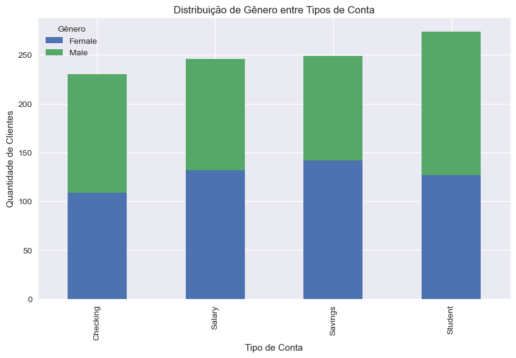

```python
# 7. Distribuição de gênero entre tipos de conta

conta_genero = pd.crosstab(df['Tipo_Conta'], df['Gênero'])

conta_genero.plot(kind='bar', stacked=True, figsize=(10,6))
plt.title('Distribuição de Gênero entre Tipos de Conta')
plt.xlabel('Tipo de Conta')
plt.ylabel('Quantidade de Clientes')
plt.legend(title='Gênero')
plt.grid(True)
plt.show()
```

```python
# 8. Quantos clientes estão com saldo negativo

saldo_negativo = df[df['Saldo_Conta'] < 0].shape[0]
print(f'Número de clientes com saldo negativo: {saldo_negativo}')
```

```
Número de clientes com saldo negativo: 26
```

```python
# 9. Perfil médio dos clientes inadimplentes (saldo < 0)

inadimplentes = df[df['Saldo_Conta'] < 0]

perfil_inadimplentes = inadimplentes[['Idade', 'Salario_Mensal', 'Limite_Cartao', 'Score_Credito']].mean()

print('Perfil médio dos clientes inadimplentes:')
print(perfil_inadimplentes)
```

```
Perfil médio dos clientes inadimplentes:
Idade                48.346154
Salario_Mensal    19279.993846
Limite_Cartao     16362.341538
Score_Credito       471.961538
dtype: float64
```